# Yulu Bike Demand Analysis

### Hypothesis Testing & Statistical Insights

**Dataset:** yulu_data.csv  
**Objective:**  
To identify the key factors affecting the demand for shared electric cycles in the Indian market using statistical hypothesis testing.

## Problem Statement

Yulu has observed a decline in its revenue and wants to understand the factors influencing the demand for shared electric cycles.  
The objective of this analysis is to identify whether demand depends on working days, seasons, and weather conditions using statistical methods.

```python
import pandas as pd
import numpy as np
import matplotlib.pyplot as plt
import seaborn as sns
```

```python
df = pd.read_csv(r"C:\Users\shubh\Downloads\yulu.csv")
df.head()
```

|  | datetime | season | holiday | workingday | weather | temp | atemp | humidity | windspeed | casual | registered | count |
| --- | --- | --- | --- | --- | --- | --- | --- | --- | --- | --- | --- | --- |
| 0 | 2011-01-01 00:00:00 | 1 | 0 | 0 | 1 | 9.84 | 14.395 | 81 | 0.0 | 3 | 13 | 16 |
| 1 | 2011-01-01 01:00:00 | 1 | 0 | 0 | 1 | 9.02 | 13.635 | 80 | 0.0 | 8 | 32 | 40 |
| 2 | 2011-01-01 02:00:00 | 1 | 0 | 0 | 1 | 9.02 | 13.635 | 80 | 0.0 | 5 | 27 | 32 |
| 3 | 2011-01-01 03:00:00 | 1 | 0 | 0 | 1 | 9.84 | 14.395 | 75 | 0.0 | 3 | 10 | 13 |
| 4 | 2011-01-01 04:00:00 | 1 | 0 | 0 | 1 | 9.84 | 14.395 | 75 | 0.0 | 0 | 1 | 1 |

```python
df.shape
```

```
(10886, 12)
```

## Dataset Overview

- Total records: 10,886
- Total features: 12

### Key Variables

- **Dependent Variable:** count (total bike rentals)
- **Independent Variables:** season, weather, workingday, holiday, temperature, humidity, windspeed

```python
df.info()
```

```
<class 'pandas.core.frame.DataFrame'>
RangeIndex: 10886 entries, 0 to 10885
Data columns (total 12 columns):
 #   Column      Non-Null Count  Dtype
---  ------      --------------  -----
 0   datetime    10886 non-null  object
 1   season      10886 non-null  int64
 2   holiday     10886 non-null  int64
 3   workingday  10886 non-null  int64
 4   weather     10886 non-null  int64
 5   temp        10886 non-null  float64
 6   atemp       10886 non-null  float64
 7   humidity    10886 non-null  int64
 8   windspeed   10886 non-null  float64
 9   casual      10886 non-null  int64
 10  registered  10886 non-null  int64
 11  count       10886 non-null  int64
dtypes: float64(3), int64(8), object(1)
memory usage: 1020.7+ KB
```

```python
df.describe()
```

|  | season | holiday | workingday | weather | temp | atemp | humidity | windspeed | casual | registered | count |
| --- | --- | --- | --- | --- | --- | --- | --- | --- | --- | --- | --- |
| count | 10886.000000 | 10886.000000 | 10886.000000 | 10886.000000 | 10886.00000 | 10886.000000 | 10886.000000 | 10886.000000 | 10886.000000 | 10886.000000 | 10886.000000 |
| mean | 2.506614 | 0.028569 | 0.680875 | 1.418427 | 20.23086 | 23.655084 | 61.886460 | 12.799395 | 36.021955 | 155.552177 | 191.574132 |
| std | 1.116174 | 0.166599 | 0.466159 | 0.633839 | 7.79159 | 8.474601 | 19.245033 | 8.164537 | 49.960477 | 151.039033 | 181.144454 |
| min | 1.000000 | 0.000000 | 0.000000 | 1.000000 | 0.82000 | 0.760000 | 0.000000 | 0.000000 | 0.000000 | 0.000000 | 1.000000 |
| 25% | 2.000000 | 0.000000 | 0.000000 | 1.000000 | 13.94000 | 16.665000 | 47.000000 | 7.001500 | 4.000000 | 36.000000 | 42.000000 |
| 50% | 3.000000 | 0.000000 | 1.000000 | 1.000000 | 20.50000 | 24.240000 | 62.000000 | 12.998000 | 17.000000 | 118.000000 | 145.000000 |
| 75% | 4.000000 | 0.000000 | 1.000000 | 2.000000 | 26.24000 | 31.060000 | 77.000000 | 16.997900 | 49.000000 | 222.000000 | 284.000000 |
| max | 4.000000 | 1.000000 | 1.000000 | 4.000000 | 41.00000 | 45.455000 | 100.000000 | 56.996900 | 367.000000 | 886.000000 | 977.000000 |

## Data Preparation

- Converted categorical variables (season, weather, workingday, holiday) to category type
- Checked for missing values (none found)
- Verified data distribution and data types

```python
df.isnull().sum()
```

```
datetime      0
season        0
holiday       0
workingday    0
weather       0
temp          0
atemp         0
humidity      0
windspeed     0
casual        0
registered    0
count         0
dtype: int64
```

```python
df["season"] = df["season"].astype("category")
df["workingday"] = df["workingday"].astype("category")
df["weather"] = df["weather"].astype("category")
df["holiday"] = df["holiday"].astype("category")
```

```python
df.info()
```

```
<class 'pandas.core.frame.DataFrame'>
RangeIndex: 10886 entries, 0 to 10885
Data columns (total 12 columns):
 #   Column      Non-Null Count  Dtype
---  ------      --------------  -----
 0   datetime    10886 non-null  object
 1   season      10886 non-null  category
 2   holiday     10886 non-null  category
 3   workingday  10886 non-null  category
 4   weather     10886 non-null  category
 5   temp        10886 non-null  float64
 6   atemp       10886 non-null  float64
 7   humidity    10886 non-null  int64
 8   windspeed   10886 non-null  float64
 9   casual      10886 non-null  int64
 10  registered  10886 non-null  int64
 11  count       10886 non-null  int64
dtypes: category(4), float64(3), int64(4), object(1)
memory usage: 723.7+ KB
```

## Univariate Analysis

- Bike rental demand is right-skewed
- Majority of days have low to moderate demand
- A small number of days show very high rentals

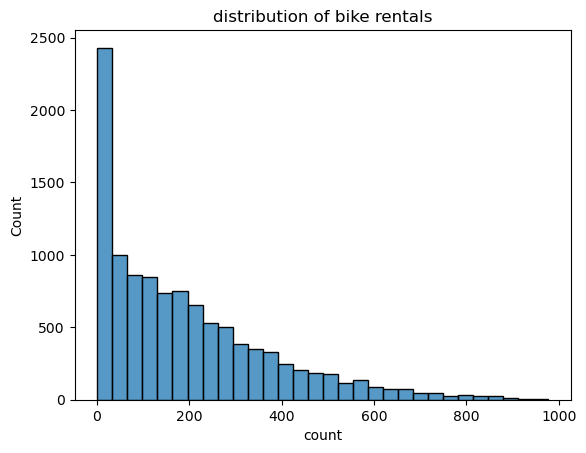

```python
sns.histplot(x = df["count"],data = df,bins = 30)
plt.title("distribution of bike rentals")
plt.show()
```

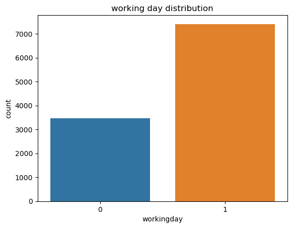

```python
sns.countplot(x = df["workingday"],data = df)
plt.title("working day distribution")
plt.show()
```

```python
# Mean bike rentals by working day
df.groupby("workingday")["count"].mean()
```

```
workingday
0    188.506621
1    193.011873
Name: count, dtype: float64
```

The average number of bike rentals on working days and non-working days is very similar, indicating limited difference in demand.

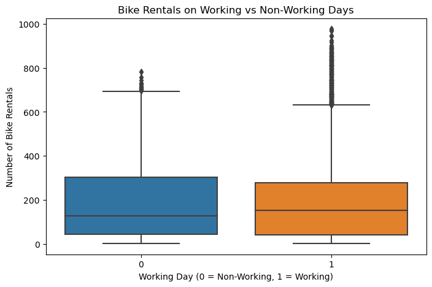

```python
plt.figure(figsize=(8,5))
sns.boxplot(x="workingday", y="count", data=df)
plt.title("Bike Rentals on Working vs Non-Working Days")
plt.xlabel("Working Day (0 = Non-Working, 1 = Working)")
plt.ylabel("Number of Bike Rentals")
plt.show()
```

```python
sns.boxplot(x = df["workingday"],data = df)
plt.title("working day distribution")
plt.show()
```

[output not shown]

### Hypothesis

- H₀: Working day has no effect on bike rentals
- H₁: Working day has an effect on bike rentals

### Result

- p-value > 0.05
- Fail to reject null hypothesis

### Conclusion

Working day does not have a statistically significant impact on bike demand.

```python
# working day vs bike rentals

# Does the number of bikes rented differ between working days and non-working days?
# H₀ (Null Hypothesis):
# There is no significant difference in the average number of bikes rented on working days and non-working days.

# H₁ (Alternate Hypothesis):
# There is a significant difference in the average number of bikes rented on working days and non-working days

workingday_1 = df[df["workingday"] == 1]["count"]
workingday_0 = df[df["workingday"] == 0]["count"]
```

```python
workingday_1.mean() , workingday_0.mean()
```

```
(193.01187263896384, 188.50662061024755)
```

```python
from scipy.stats import ttest_ind

t_stat , p_value = ttest_ind(workingday_1,
                             workingday_0,
                             equal_var = False)
t_stat, p_value
```

```
(1.2362580418223226, 0.21640312280695098)
```

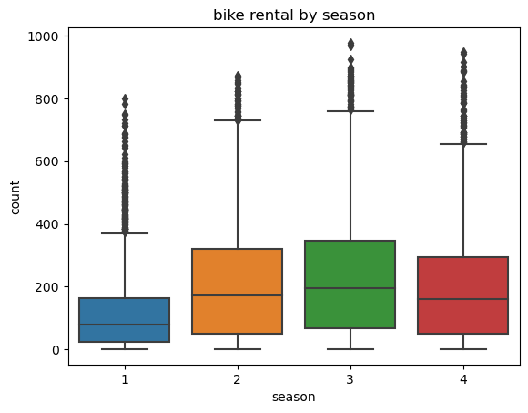

```python
sns.boxplot(x= "season",y = "count",data = df)
plt.title("bike rental by season")
plt.show()
```

### Season vs Bike Rentals (ANOVA)

- H₀: Mean rentals are same across all seasons
- H₁: Mean rentals differ across seasons

### Result

- p-value < 0.05
- Reject null hypothesis

### Conclusion

Bike rental demand varies significantly across seasons.

```python
from scipy.stats import f_oneway

spring = df[df["season"] == 1]["count"]
summer = df[df["season"] == 2]["count"]
fall = df[df["season"] == 3]["count"]
winter = df[df["season"] == 4]["count"]

f_stat , p_value = f_oneway(spring , summer , fall, winter)
f_stat , p_value
```

```
(236.94671081032106, 6.164843386499654e-149)
```

### Weather vs Bike Rentals (ANOVA)

```python
clear = df[df["weather"] == 1]["count"]
mist = df[df["weather"] == 2]["count"]
light_rain = df[df["weather"] == 3]["count"]
heavy_rain = df[df["weather"] == 4]["count"]


f_stat, p_value = f_oneway(clear , mist, light_rain,heavy_rain)
f_stat , p_value
```

```
(65.53024112793271, 5.482069475935669e-42)
```

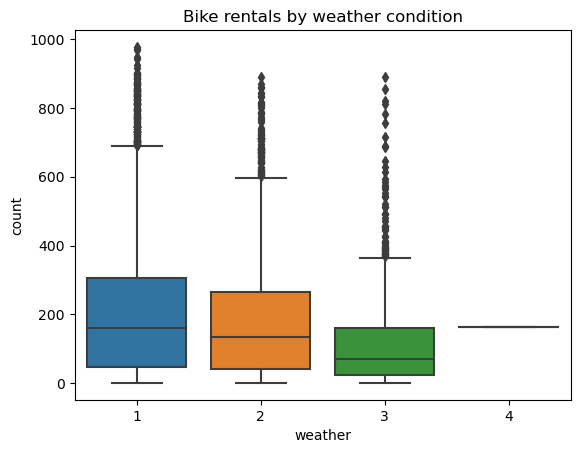

```python
sns.boxplot(x= "weather",y= "count",data = df)
plt.title("Bike rentals by weather condition")
plt.show()
```

### Season vs Weather (Chi-Square Test)

- H₀: Weather is independent of season
- H₁: Weather is dependent on season

### Result

- p-value < 0.05
- Reject null hypothesis

### Conclusion

Weather conditions are dependent on seasons.

```python
contingency_table = pd.crosstab(df["season"],df["weather"])
contingency_table
```

| weather season | 1 | 2 | 3 | 4 |
| --- | --- | --- | --- | --- |
| 1 | 1759 | 715 | 211 | 1 |
| 2 | 1801 | 708 | 224 | 0 |
| 3 | 1930 | 604 | 199 | 0 |
| 4 | 1702 | 807 | 225 | 0 |

```python
from scipy.stats import chi2_contingency
chi2_stat , p_value , dof,expected = chi2_contingency(contingency_table)
chi2_stat , p_value
```

```
(49.158655596893624, 1.549925073686492e-07)
```

## Final Insights

- Season and weather are the strongest drivers of bike demand
- Working day status has minimal impact
- Demand is highly sensitive to environmental factors

## Recommendations

- Increase fleet size during summer and fall
- Use weather forecasts for dynamic deployment
- Offer discounts during mild weather disruptions
- Schedule maintenance during low-demand periods

## Conclusion

Yulu’s bike demand is driven more by environmental factors than calendar-based factors.  
Season-aware and weather-aware planning can help Yulu improve utilization and revenue.